# mapply

monoyamada

2021-11-11

# Setup

Top

```css
span.mod-date{font-size:small}.note{position:relative;margin-top:2em;margin-bottom:2em;padding:1ex 2ex;border-width:1px;border-style:solid;border-radius:15px}.note .title{position:absolute;top:0;left:0;font-size:1em;padding:0 1em;margin:0;background-color:#fff;transform:translateY(-2ex) translateX(1em)}.proof{border-left-style:solid;margin-top:1ex;margin-bottom:1ex;padding-left:1ex}.svg_box{margin-top:1ex;margin-bottom:1ex}.rokaru text{fill:black}.rokaru rect{fill:black}@media (prefers-color-scheme:dark){.rokaru text{fill:white}.rokaru rect{fill:white}}
```

```r
fw = 4;
fh = 4;
knitr::opts_chunk $ set (
 comment = ''
 , echo = T
 , cache = T
 , fig.width = fw
 , fig.height = fh
 , class.source = 'numberLines lineAnchors'
 );
knitr::set_alias (fw = 'fig.width', fh = 'fig.height', anime = 'animation.hook');
use_rcpp = F;
```

# Summary

In the previous note, we used the [monoidal functor](https://ncatlab.org/nlab/show/monoidal+functor) of List monad. In this note, we consider the other monoidal functors to imitate `mapply`.

```haskell
{-# LANGUAGE InstanceSigs #-}
{-# LANGUAGE GeneralizedNewtypeDeriving #-}

import Control.Monad (ap, forM)
import Control.Applicative (liftA2, ZipList (..))
import Data.List.NonEmpty (NonEmpty (..))
import qualified Data.List.NonEmpty as NonEmpty
import qualified Test.QuickCheck as QuickCheck
import Test.QuickCheck (quickCheck, quickCheckWith, stdArgs, maxSuccess, Fun (..), Positive (..), NonNegative (..))

type Hom a b = a -> b

hom_to cd ab bc = cd . bc . ab
hom_snd = (.)
hom_fst = flip hom_snd
clip = flip id
tom_to (ax, by) (a, b) = (ax a, by b)
tom_fst ax = tom_to (ax, id)
tom_snd by = tom_to (id, by)
alpha_fw ((a, b), c) = (a, (b, c))
alpha_bw (a, (b, c)) = ((a, b), c)
```

```python
import copy;
import numpy;
import operator;
import itertools;
import collections;
```

# Getting started

We start from the following function:

```haskell
zip_just :: (a -> b -> c) -> [a] -> [b] -> [c]
zip_just abc as bs
 | length as == length bs = [abc (as !! j) (bs !! j) | j <- js]
 | otherwise              = undefined
 where
  js = [0 .. (length as - 1)]
```

The behavior of `zip_just` is similar to `mapply`, but it’s domain is very limited. `zip_just abc as bs` works only when `length as == length bs` holds. In programming, IMHO, `zip_just` is the best from as a function in basic libraries because it helps us to preventing from bugs of *index out of bounds*. However, we consider to extend `zip_just` to be the [total function](https://en.wikipedia.org/wiki/Partial_function).

### Total function

The phrase *total function* depends on *total domain*. Actually, if we were assuming the type $A∗B:=⊔n∈NAn×Bn$, `zip_just` would be a *total function*. Here, we used the phrase *total function* as a mean of a function whose domain is written by builtin types of ordinal programming languages.

There might be programming languages that we can easily define the type $A∗B$. However, in such a case, we can’t perform naive currying to $A∗B→C$, then it brings us the other difficulties.

## `zip_min`

The following `zip_min` might be one of the easiest extensions of `zip_just`:

```haskell
zip_min :: (a -> b -> c) -> [a] -> [b] -> [c]
zip_min abc as bs = [abc (as !! j) (bs !! j) | j <- js] where
 js = [0 .. (n - 1)]
 n = min (length as) (length bs)
```

Let’s consider the following question: zip_min_assoc

- Does `zip_min` preserve associativities?

As an example, we test for the concatenation of strings.

```haskell
test_associativitiy :: (Monoid a, Eq a) => [a] -> [a] -> [a] -> Bool
test_associativitiy fa fb fc = lhs == rhs where
 lhs = (fa %*% fb) %*% fc
 rhs = fa %*% (fb %*% fc)
 (%*%) = zip_min (<>)

test_concatenation :: [String] -> [String] -> [String] -> Bool
test_concatenation = test_associativitiy

quickCheck test_concatenation
```

This test shows that `zip_min (++)` is associative, and hence, the answer to zip_min_assoc is *yes* for the case of `(++)`.

Now we’d like to answer zip_min_assoc for general cases.

`zip_min` can be rewritten as follows:

```haskell
zip_reader :: (a -> b -> c) -> (p -> q -> r) -> (Hom x a, p) -> (Hom x b, q) -> (Hom x c, r)
zip_reader abc pqr ap bq = (liftA2 abc, pqr) %<% ap %<% bq where
 (%<%) = tom_to

zip_min :: (a -> b -> c) -> [a] -> [b] -> [c]
zip_min abc as bs = to_list $ zip_reader abc min (to_map as) (to_map bs) where
 to_map xs = ((!!) xs, length xs)
 to_list (ja, n) = [ja j | j <- [0 .. (n - 1)]]
```

`liftA2` in `zip_reader` is the one of Reader monad.

`to_map` and `to_list` are inverse of each other, i.e. both `to_map . to_list == id` and `to_list . to_map == id` hold. By using this fact, `test_associativitiy` is rewritten as follows: test_zip_min

```haskell
test_associativitiy :: (Monoid a, Eq a) => [a] -> [a] -> [a] -> Bool
test_associativitiy fa fb fc = lhs == rhs where
 lhs = to_list $ (to_map fa %*% to_map fb) %*% to_map fc
 rhs = to_list $ to_map fa %*% (to_map fb %*% to_map fc)
 (%*%) = zip_reader (<>) min
 to_map xs = ((!!) xs, length xs)
 to_list (ja, n) = [ja j | j <- [0 .. (n - 1)]]

test_concatenation :: [String] -> [String] -> [String] -> Bool
test_concatenation = test_associativitiy

quickCheck test_concatenation
```

Then the problem comes down to the associativity of `zip_reader (<>) min`. We know that `zip_reader (<>) min` is associative thanks to the following facts:

1. `liftA2 (<>)` is associative.
2. `min` is associative.
3. If both `f :: a -> a -> a` and `g :: x -> x -> x` are associative, then the tuple `(f, g)` is associative under the element-wise application.

Note that, in the third statement above, *element-wise* means *element-wise* of a tuple but not of an array.

Finally, the unit of `zip_min (<>)` is given by the following:

```haskell
zip_min_unit :: (Monoid a) => [a]
zip_min_unit = repeat mempty
```

Note that the unit of `min` is an infinite length array.

## `zip_lcm`

We define `zip_mod` by extending `zip_min` as follows: zip_mod

```haskell
zip_mod :: (Int -> Int -> Int) -> (a -> b -> c) -> [a] -> [b] -> [c]
zip_mod pqr abc as bs = to_list $ zip_reader abc pqr (to_map as) (to_map bs) where
 to_map xs = (\j -> xs !! mod j n, n) where n = length xs
 to_list (ja, n) = [ja j | j <- [0 .. (n - 1)]]
```

By using `zip_mod`, we define `zip_lcm` as follows:

```haskell
zip_lcm = zip_mod lcm
```

Contrast to the previous section, `to_map` and `to_list` in `zip_mod` aren’t inverse each others. `to_list . to_map == id` still holds but `to_map . to_list` isn’t the identity. `to_map . to_list` makes a function being cyclic as follows:

```haskell
to_map_to_list :: (Hom Int a, Int) -> (Hom Int a, Int)
-- to_map_to_list = to_map . to_list where
to_map_to_list (ja, na) = (cyclic ja na, na) where
 -- cyclic ja na k = [ja j | j <- [0 .. (na - 1)]] !! mod k na
 cyclic ja na = ja . (`mod` na)
 to_map xs = (\j -> xs !! mod j n, n) where n = length xs
 to_list (ja, n) = [ja j | j <- [0 .. (n - 1)]]
```

We modify test_zip_min as follows:

```haskell
mod_associativitiy :: (Monoid a, Eq a) => (Int -> Int -> Int) -> [a] -> [a] -> [a] -> Bool
mod_associativitiy pqr fa fb fc = lhs == rhs where
 lhs = to_list $ cyclic (to_map fa %*% to_map fb) %*% to_map fc
 rhs = to_list $ to_map fa %*% cyclic (to_map fb %*% to_map fc)
 (%*%) = zip_reader (<>) pqr
 to_map xs = (\j -> xs !! mod j n, n) where n = length xs
 to_list (ja, n) = [ja j | j <- [0 .. (n - 1)]]
 cyclic (f, n) = (f . (`mod` n), n)

mod_concatenation :: (Int -> Int -> Int) -> [String] -> [String] -> [String] -> Bool
mod_concatenation = mod_associativitiy

quickCheck $ mod_concatenation lcm
```

The main difference of this test from test_zip_min is the existence of `cyclic`. Whereas each `cyclic` in `mod_associativitiy` effectively becomes `id` thanks to the properties of `lcm` and `to_map`.

By taking account that the unit of `lcm` is $1$, the unit of `zip_lcm (<>)` is given by the following:

```haskell
zip_lcm_unit :: (Monoid a) => [a]
zip_lcm_unit = pure mempty
```

Recall that the unit of `zip_min` is an infinite length array. To make the difference clear, we arrange `zip_min` and `zip_lcm` in the form of Applicative.

```haskell
newtype ZipMin a = ZipMin {
 runZipMin :: [a]
 } deriving (Eq, Show, Functor)

newtype ZipLcm a = ZipLcm {
 runZipLcm :: [a]
 } deriving (Eq, Show, Functor)

instance Applicative ZipMin where
 pure :: a -> ZipMin a
 pure a = ZipMin $ repeat a

 liftA2 :: (a -> b -> c) -> ZipMin a -> ZipMin b -> ZipMin c
 liftA2 abc (ZipMin a) (ZipMin b) = ZipMin $ zip_min abc a b

instance Applicative ZipLcm where
 pure :: a -> ZipLcm a
 pure a = ZipLcm [a]

 liftA2 :: (a -> b -> c) -> ZipLcm a -> ZipLcm b -> ZipLcm c
 liftA2 abc (ZipLcm a) (ZipLcm b) = ZipLcm $ zip_lcm abc a b
```

The difference between the `pure`s of `zip_min` and `zip_lcm` is visible in Python as follows:

```python
def none ():
 min_pure = lambda a: itertools.repeat (a);
 lcm_pure = lambda a: numpy.array ([a]);
 a = numpy.array (range (3));
 print (
  10 + a
  , a + 10
  , a + lcm_pure (10)
  , numpy.fromiter (map (operator.add, a, min_pure (10)), int)
  , numpy.fromiter (map (operator.add, a, lcm_pure (10)), int)
  , sep = "\n");
 return None;
none ();
```

```
[10 11 12]
[10 11 12]
[10 11 12]
[10 11 12]
[10]
```

The [numpy.broadcast](https://numpy.org/doc/stable/reference/generated/numpy.broadcast.html) works similar to the `pure` of `zip_lcm`. On the other hand, `map` in Python is essentially `zip_min`, therefore we have to use `map` with `min_pure (10)` to obtain the same result of `a + 10`.

## Comparing to List monad

The difference between `liftA2` of List monad and `zip_lcm` is easy to understand in the form of [list comprehension](https://en.wikipedia.org/wiki/List_comprehension).

```haskell
list_monad_case :: (a -> b -> c) -> [a] -> [b] -> [c]
-- list_monad_case = liftA2
list_monad_case abc as bs = [abc (to_map as j) (to_map bs k) | j <- js, k <- ks] where
 to_map = (!!)
 js = [0 .. (length as - 1)]
 ks = [0 .. (length bs - 1)]

zip_lcm_case :: (a -> b -> c) -> [a] -> [b] -> [c]
-- zip_lcm_case = zip_lcm
zip_lcm_case abc as bs = [abc (to_map as j) (to_map bs j) | j <- js] where
 to_map xs j = xs !! mod j (length xs)
 js = [0 .. (lcm (length as) (length bs) - 1)]
```

In `list_monad_case`, there are two indices within the list comprehension. These two indices run independently within the list comprehension. On the other hand, there is only one index within the list comprehension in `zip_lcm_case`. This single loop behavior of `zip_lcm` is similar to the one of `liftA2` of Reader monad. By the definition of `zip_mod`, this similarity is obvious.

# Relevance to `mapply`

`zip_lcm` works like that:

```haskell
zip_lcm (,) [1 .. 2] ""     -- []
zip_lcm (,) [1 .. 2] "a"    -- [(1,'a'),(2,'a')]
zip_lcm (,) [1 .. 2] "ab"   -- [(1,'a'),(2,'b')]
zip_lcm (,) [1 .. 2] "abc"  -- [(1,'a'),(2,'b'),(1,'c'),(2,'a'),(1,'b'),(2,'c')]
zip_lcm (,) [1 .. 2] "abcd" -- [(1,'a'),(2,'b'),(1,'c'),(2,'d')]
```

We classify the behavior of `zip_lcm` by it’s arguments. Let `na := length as` and `nb := length bs` in `zip_lcm abc as bs`, the classification is the following:

1. if `min na nb == 0`, then the output is the empty list.
2. if `na` is a multiple of `nb` or vise versa, then the output is similar to `mapply (abc, as, bs, SIMPLIFY = F)`.
3. if `na` and `nb` are [coprime](https://en.wikipedia.org/wiki/Coprime_integers), then output is similar to `outer (abc, as, bs)` but the order of elements of the output is different.

`mapply` works like that:

```r
none = with (new.env (), {
 xy = \(x, y) tibble::tibble (x = x, y = y);
 mapp = \(abc) \(a, b) mapply (abc, a, b, SIMPLIFY = F);

 # mapp (xy) (1 : 2, c ())                   |> dplyr::bind_rows () |> print ();
 mapp (xy) (1 : 2, c ("a"))                |> dplyr::bind_rows () |> print ();
 mapp (xy) (1 : 2, c ("a", "b"))           |> dplyr::bind_rows () |> print ();
 mapp (xy) (1 : 2, c ("a", "b", "c", "d")) |> dplyr::bind_rows () |> print ();
});
```

```
# A tibble: 2 × 2
      x y
  <int> <chr>
1     1 a
2     2 a
# A tibble: 2 × 2
      x y
  <int> <chr>
1     1 a
2     2 b
# A tibble: 4 × 2
      x y
  <int> <chr>
1     1 a
2     2 b
3     1 c
4     2 d
```

We have the following sequence of partial functions reaching to the total function `zip_lcm`:
$$zip_just→extendpurrr::map2→extendmapply→extendzip_lcm.$$

Many [binary operations](https://en.wikipedia.org/wiki/Binary_operation) in R are seemed like according to the style of `mappy`, i.e. *shorter lists are cycled*[^1]. In terms of this note, many binary operations in R are translated from scalar operations by using `zip_lcm`.

```r
none = with (new.env (), {
 test_it = \(expr) testthat::test_that ("", expr);
 test_eq = testthat::expect_equal;
 mapp = \(abc) \(a, b) mapply (abc, a, b, SIMPLIFY = F);

 test_it ({
  a = 1 : 2;
  b = 3 : 4;
  test_eq (`+`    (a, b), mapp (`+`)    (a, b) |> unlist ());
  test_eq (pmax   (a, b), mapp (max)    (a, b) |> unlist ());
  test_eq (`<`    (a, b), mapp (`<`)    (a, b) |> unlist ());
  test_eq (paste0 (a, b), mapp (paste0) (a, b) |> unlist ());
 });
});
```

```
Test passed 😀
```

In this case, the monoidal functor `zip_lcm` plays a role of providing a set of binary operations with a unified [look and feel](https://en.wikipedia.org/wiki/Look_and_feel). This unification helps us to reduce the frequency of referring to manuals, and hence, contributes to productivity of programming.

# Tidy and Linq

To be honest, I don’t know [Linq](https://en.wikipedia.org/wiki/Language_Integrated_Query). However as far as seeing the example listed in the article, the main gadget of Linq is looked like a *list of records*.

```
var results =  from c in SomeCollection
               where c.SomeProperty < 10
               select new {c.SomeProperty, c.OtherProperty};

foreach (var result in results) {
 Console.WriteLine (result);
}
```

On the other hand, the main gadget of [Tidyverse](https://www.tidyverse.org/) is looked like a [spreadsheet](https://en.wikipedia.org/wiki/Spreadsheet), i.e. a *record of lists*. The correspondence between a *list of records* and a *record of lists* is given by tidy-linq-py

```python
def none ():
 AB = collections.namedtuple ("AB", ("a", "b"));
 tidy = AB (tuple (range (3)), tuple ("abc"));
 linq = list (map (AB, *tidy));
 back = AB (*zip (*linq));
 print (tidy, linq, back, sep = "\n");
 return None;
none ();
```

```
AB(a=(0, 1, 2), b=('a', 'b', 'c'))
[AB(a=0, b='a'), AB(a=1, b='b'), AB(a=2, b='c')]
AB(a=(0, 1, 2), b=('a', 'b', 'c'))
```

This correspondence is fairly similar to the definition of product. The following is a test whether `(,)` is a product or not:

```haskell
product_fw :: (Hom x a, Hom x b) -> Hom x (a, b)
product_fw = uncurry $ liftA2 (,)

product_bw :: Hom x (a, b) -> (Hom x a, Hom x b)
product_bw = NonEmpty.unzip

test_bw_fw :: (Fun Int Int, Fun Int Int) -> Int -> Int -> Bool
test_bw_fw (Fun _ xa, Fun _ xb) x y = lhs == rhs where
 lhs = (ya x, yb y)
 (ya, yb) = product_bw $ product_fw (xa, xb)
 rhs = (xa x, xb y)

test_fw_bw :: Fun Int (Int, Int) -> Int -> Bool
test_fw_bw (Fun _ xab) x = lhs == rhs where
 lhs = (product_fw $ product_bw xab) x
 rhs = xab x

quickCheck test_bw_fw
quickCheck test_fw_bw
```

The correspondence between Tidy and Linq is given by `rproduct_fw` and `product_bw` as follows:

```haskell
tidy_to_linq :: ([a], [b]) -> [(a, b)]
tidy_to_linq (as, bs) = to_list $ product_fw (to_map as, to_map bs) where
 to_map = (!!)
 to_list ja = map ja [0 .. (n - 1)]
 n = if na == nb then na else undefined
 na = length as
 nb = length bs

linq_to_tidy :: [(a, b)] -> ([a], [b])
linq_to_tidy abs = tom_to (to_list, to_list) $ product_bw $ to_map abs where
 to_map = (!!)
 to_list ja = map ja [0 .. (n - 1)]
 n = length abs

test_tidy_to_tidy :: [(Int, Int)] -> Bool
test_tidy_to_tidy zipped_ab = lhs ab == ab where
 lhs = linq_to_tidy . tidy_to_linq
 ab = NonEmpty.unzip zipped_ab

test_linq_to_linq :: [(Int, Int)] -> Bool
test_linq_to_linq ab = lhs ab == ab where
 lhs = tidy_to_linq . linq_to_tidy

quickCheck test_tidy_to_tidy
quickCheck test_linq_to_linq
```

Usually we aren’t aware of the Reader monad though, it often exists in the behind of fundamental facts.

`tidy_to_linq` is essentially `zip_just`.

```haskell
tidy_to_linq_is_zip_just :: [(Int, Int)] -> Bool
tidy_to_linq_is_zip_just zab = tidy_to_linq (a, b) == zip_just (,) a b where
 (a, b) = unzip zab

quickCheck tidy_to_linq_is_zip_just
```

Therefore the correspondence between Tidy and Linq is also written by either `zip_min` or `zip_lcm` instead of Reader monad. The Python code tidy-linq-py shows the correspondence of Tidy and Linq by using `zip_nin`.

# Going to the product

`zip_min`, `zip_lcm`, and additionally `liftA2` of List monad are summarized as follows:
$$(mll)zip_min[[[p]],A]⊗[[[q]],B]→[ι,1]⊗[ι,1][[[min(p,q)]],A]⊗[[[min(p,q)]],B]→product_fw[[[min(p,q)]],A⊗B],zip_lcm[[[p]],A]⊗[[[q]],B]→[modp,1]⊗[modq,1][[[lcm(p,q)]],A]⊗[[[lcm(p,q)]],B]→product_fw[[[lcm(p,q)]],A⊗B],List monad[X,A]⊗[Y,B]→[fst,1]⊗[snd,1][X×Y,A]⊗[X⊗Y,B]→product_fw[X⊗Y,A⊗B],$$
where $[[p]]={0,…,p−1∈N}$ be a set of [zero-based indices](https://en.wikipedia.org/wiki/Zero-based_numbering), $ι$ is an [inclusion map](https://en.wikipedia.org/wiki/Inclusion_map). Are there a pattern?

Let $(A,⋅,i)$ be a [cartesian monoidal category](https://ncatlab.org/nlab/show/cartesian+monoidal+category) with

1. the projections $a←ρ1a⋅b→ρ2b$,
2. the associator $β:(a⋅b)⋅c→a⋅(b⋅c)$,

and $F$ be a functor $F:A→Set$.

We define the natural transformation $μ$ as follows:
$$(product-mu)[Fa,A]⊗[Fb,B]→μ[F(a⋅b),A⊗B]:=[Fa,A]⊗[Fb,B]→[Fρ1,1]⊗[Fρ2,1][F(a⋅b),A]⊗[F(a⋅b),B]→product_fw[F(a⋅b),A⊗B]$$
$μ$ is looked like to reproduce the above summary $(mll)$. In the case of List monad, by taking $Set$ itself and $1Set$ for $A$ and $F$, respectively, $μ$ reproduces $(mll)$. For the cases of `zip_min` and `zip_lcm`, the configuration of $A$ and $F$ are the followings:

### zip_min

Let $A$ be the following [posetal category](https://ncatlab.org/nlab/show/thin+category):

1. an object is either a natural number or infinity $∞$.
2. a morphism $p→q$ is defined iff $p≤q$.

The set of objects of $A$ is $N∪{∞}$, and a morphism is the relation $p→≤q$. The initial and terminal objects of $A$ are $0$ and $∞$, respectively.

The product and coproduct of $p,q∈A$ are given by $min(p,q)$ and $max(p,q)$, respectively. We visualize this by pullback/pushout diagram as follows:
$$min(p,q)qpmax(p,q)pullback / pushout.$$
The unit object of product $min$ is the terminal object $∞$.

We define the functor $F:A→Set$ as follows:
$$F(p→q):=[[p]]→ι[[q]].$$
A posetal morphism is mapped to an inclusion map.

### zip_lcm

Let $A$ be the posetal category of followings:

1. an object is a natural number,
2. a morphism $p→q$ iff $q$ is a multiple of $p$.

The set of objects of $A$ is $N$, and a morphism is the relation $p→qp∈Nq$. The initial and terminal objects of $A$ are $1$ and $0$, respectively.

The product and coproduct of $p,q∈A$ are given by
$$gcd(p,q)qplcm(p,q)pullback / pushout.$$
The counit object of coproduct $lcm$ is the initial object $1$.

We define the functor $F:Aop→Set$ as follows:
$$F(p→q)op:=[[q]]→modp[[p]].$$
Note that the roles of product and coproduct are inverted in the opposite category. Hence $lcm$ is a product in $Aop$, and $1$ is a unit object of $lcm$ in $Aop$. A mapped morphism $modp$ corresponds to the function `to_map` in zip_mod.

## Preserving monoids

We show several properties so that $(product-mu)$ preserves monoids.

The associativity of $μ$ is ensured by the associativity of $(⋅)$:
$$([Fa,A]⊗[Fb,B])⊗[Fc,C]μ⊗1α[F(a⋅b),A⊗B]⊗[Fc,C]μ[F((a⋅b)⋅c),(A⊗B)⊗C][Fβ−1,α][Fa,A]⊗([Fb,B]⊗[Fc,C])1⊗μ[Fa,A]⊗[F(b⋅c),B⊗C]μ[F(a⋅(b⋅c)),A⊗(B⊗C)],$$
where $α$ is the associators of $(⊗)$ in $Set$.

`product_fw` makes the following diagram commuting:
$$(dup)Bfop[B,X]⊗[B,Y]product_fw[f,1]⊗[f,1][B,X⊗Y][f,1]A[A,X]⊗[A,Y]product_fw[A,X⊗Y].$$
By using this, the diagram of proposition is rewritten as follows:
$$([Fa,A]⊗[Fb,B])⊗[Fc,C]([Fρ11,1]⊗[Fρ21,1])⊗[Fρ2,1]([Fρ1,1]⊗[Fρ12,1])⊗[Fρ22,1]([F((a⋅b)⋅c),A]⊗[F((a⋅b)⋅c),B])⊗[F((a⋅b)⋅c),C]([Fβ−1,1]⊗[Fβ−1,1])⊗[Fβ−1,1]([F(a⋅(b⋅c)),A]⊗[F(a⋅(b⋅c)),B])⊗[F(a⋅(b⋅c)),C]α?([F(a⋅(b⋅c)),A]⊗[F(a⋅(b⋅c)),B])⊗[F(a⋅(b⋅c)),C]product_fw⊗1⋯⋯,$$
where $ρjk$ is the composition $ρjk:=ρj∘ρk$, the questioned equality $=?$ is what we have to prove. The rest part of diagram, i.e. the lower incomplete part, is the standard associativity diagram of `product_fw`. Since we already know that the standard associativity diagram of `product_fw` commutes, the only thing that we have to prove is the following diagram commuting:
$$(F((a⋅b)⋅c)⊗F((a⋅b)⋅c))⊗F((a⋅b)⋅c)(Fρ11⊗Fρ21)⊗Fρ2[Fβ⊗Fβ]⊗Fβ(Fa⊗Fb)⊗Fc?(F(a⋅(b⋅c))⊗F(a⋅(b⋅c)))⊗F(a⋅(b⋅c))(Fρ1⊗Fρ12)⊗Fρ22(Fa⊗Fb)⊗Fc.$$
By checking each component of tensor product $(⊗)$, we know that this diagram commutes thanks to $A$ being cartesian category, and hence, we can erase the question of $=?$ in this diagram. Thus the proposition has been proven.

The following diagram commutes:
$$I⊗[Fa,A]const⊗1snd|I[Fi,I]⊗[Fa,A]μ[Fa,A][F(i⋅a),I⊗A][Fρ2|i−1,snd|I],$$
where

1. $snd|I:I⊗A≃A$ is the restriction of projection $snd$ to $I⋅A$. By this restriction, $snd|I$ is invertible,
2. $ρ2|i:i⋅a≃a$ is similar restriction to $snd|I$.

This diagram is similar to the [unit diagrams](https://ncatlab.org/nlab/show/monoidal+functor) of monoidal functor, and hence, it plays a role to ensure preserving the unit of monoid.

By using $(dup)$, we have
$$I⊗[Fa,A]const⊗1snd|Iconst⊗1[Fi,I]⊗[Fa,A][Fρ1,1]⊗[Fρ2|i,1][F(ρ1∘ρ2)|i−1,1]⊗1[Fa,I]⊗[Fa,A]product_fw[F(i⋅a),I]⊗[F(i⋅a),A]product_fw[Fρ2|i−1,1]⊗[Fρ2|i−1,1][Fa,A][Fa,I⊗A][1,snd|I][F(i⋅a),I⊗A][Fρ2|i−1,1].$$
Thus the proof of proposition boils down to showing the left bottom diagram of this diagram commuting. By the unitality of `product_fw` and the invertibility of $snd|I$, we can show that the left bottom diagram of this diagram commutes. Thus the proposition has been proven.

## Reader monad

Reader monad can be regard as follows:

- *composition of maps* + *fundamental tuple operations*.

`pure` and `join` of Reader monad are given by the projection `fst` and duplication `dup`, respectively.
$$[A,C]fst⊗1[1,pure][A⊗B,C]curry[A,[B,C]],[A⊗A,B]curry[dup,1][A,[A,B]]join[A,B].$$
The other projection `snd` is usually used in the following from:
$$[B,C]snd⊗1ϕ[A⊗B,C]curry[A,[B,C]]⟹1Set→ϕ(1B)[B,B].$$
By putting $L:=(.)$, $i:=pure$, $j:=ϕ(1X)$, they form the axiom of [closed category](https://ncatlab.org/nlab/show/closed+category).

In this note, we are interested in `liftA2` of Reader monad. `liftA2` of Reader monad is essentially `dup` as follows:

```haskell
dup :: a -> (a, a)
dup a = (a, a)

product_fw :: (Hom x a, Hom x b) -> Hom x (a, b)
-- product_fw = uncurry $ liftA2 (,)
-- product_fw (xa, xb) = tom_to (xa, xb ). dup
product_fw = hom_fst dup . tom_to
```

We can understand that the zip nature of Reader monad comes from `dup` of tuple.

It is rarely said that the tuple is a monad. In R, `pairlist` is a monad. The following functors between the category of sets and its
[product category](https://en.wikipedia.org/wiki/Product_category) forms an [adjunction](https://en.wikipedia.org/wiki/Adjoint_functors):
$$Set⇄(⊗)DupSet×Set,$$
where
$$Dup(A→fB):=A×A→f×fB×B,(⊗)(A×X→f×gB×Y):=A⊗X→f⊗gB⊗X.$$
The monad toolkit of tuple monad is the following:

```haskell
tuple_fmap :: Hom a b -> Hom (a, a) (b, b)
tuple_fmap = tom_to . dup

tuple_pure :: a -> (a, a)
tuple_pure = dup

tuple_join :: ((a, b), (c, d)) -> (a, d)
tuple_join = tom_to fst snd
```

# Memorandum

## Partial application in Python

- [6. Expressions — Python 3.10.0 documentation](https://docs.python.org/3/reference/expressions.html#operator-precedence)
- [operator — Standard operators as functions — Python 3.10.0 documentation](https://docs.python.org/3/library/operator.html)

```python
class Pa:
 def __init__ (self, f, *args, **kwargs):
  self.f = f;
  self.args = args;
  self.kwargs = kwargs;
 def add_rr (self, *args):
  self.args = self.args + args;
  return self;
 def add_ll (self, *args):
  self.args = args + self.args;
  return self;
 def set (self, **kwargs):
  self.kwargs.update (**kwargs);
  return self;
 def call (self):
  return self.f (*self.args, **self.kwargs);
 def __lshift__ (self, *args):
  return self.add_rr (*args);
 def __rshift__ (self, *args):
  return self.add_ll (*args);

def none ():
 A = collections.namedtuple ("A", ("a", "b", "c", "d"));
 _ = Pa (A, d = "world") << 1 >> True << "hello";
 print (_.call ());
 return None;
none ();
```

```
A(a=True, b=1, c='hello', d='world')
```

## Example of fiber bundle

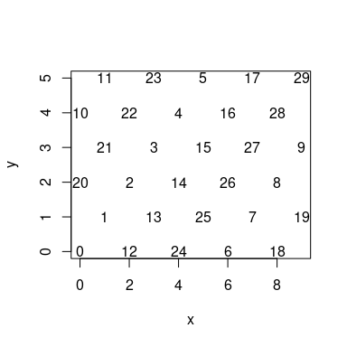

```r
none = with (new.env (), {
 xyz = \(x, y, z) tibble::tibble (x = x, y = y, z = z);
 nx = 10;
 ny = 6;
 n = numbers::LCM (nx, ny);
 out = purrr::map (1 : n, \(n) {
  n = n - 1;
  xyz (n %% nx, n %% ny, n);
 }) |> dplyr::bind_rows ();
 with (out, {
  plot (x, y, type = "n");
  text (x, y , lab = z);
 });
});
```

## Fibered product

The phrase *fibered product*[^2] could be rephrased as the *column-wise* product in terms of spreadsheet. For example, let’s consider the following pullback:
$$(column-wise){0,2}×{0,2,4}⏟fiber over 0+{1,3}×{1,3,5}⏟fiber over 1π1π2[[2⋅2]]mod2[[2]][[2⋅3]]mod2.$$
Each fiber bundle over the base space $[[2]]$ in this picture can be written in the form of spreadsheet as follows:
$$[[2⋅2]]=2301,[[2⋅3]]=452301.$$
The pullback of $(column-wise)$ is obtained by taking the cartesian product of $[[2⋅2]]$ and $[[2⋅2]]$ *column-wisely*.

```r
none = with (new.env (), {
 a_2_2 = 2L * rev (0 : 1);
 a_2_2 = tibble::tibble (x = a_2_2, y = a_2_2 + 1L);
 a_2_3 = 2L * rev (0 : 2);
 a_2_3 = tibble::tibble (x = a_2_3, y = a_2_3 + 1L);
 b_2_2 = tidyr::pivot_longer (a_2_2, cols = c (x, y), values_to = "b_2_2");
 b_2_3 = tidyr::pivot_longer (a_2_3, cols = c (x, y), values_to = "b_2_3");
 out = dplyr::inner_join (b_2_2, b_2_3, by = "name");
 print (a_2_2);
 print (a_2_3);
 print (out);
});
```

```
# A tibble: 2 × 2
      x     y
  <int> <int>
1     2     3
2     0     1
# A tibble: 3 × 2
      x     y
  <int> <int>
1     4     5
2     2     3
3     0     1
# A tibble: 12 × 3
   name  b_2_2 b_2_3
   <chr> <int> <int>
 1 x         2     4
 2 x         2     2
 3 x         2     0
 4 y         3     5
 5 y         3     3
 6 y         3     1
 7 x         0     4
 8 x         0     2
 9 x         0     0
10 y         1     5
11 y         1     3
12 y         1     1
```

[^1]: Map (higher-order function) - Wikipedia
[^2]: [pullback in nLab](https://ncatlab.org/nlab/show/pullback)